# Case III — Galeries Lafayette

Lina Simonian & Elena Pshenichnikova

2025-04-25

# 1 **Introduction**

In response to declining sales performance, Galeries Lafayette has initiated a comprehensive research project aimed at deepening the understanding of customer perceptions and their impact on brand loyalty and engagement. This study focuses on identifying the key perceptual dimensions that shape the image of Galeries Lafayette and evaluating how these perceptions influence customer satisfaction, affective commitment, and behavioral intentions such as repurchase and co-creation.

## 1.1 **Data overview**

```r
# Explore the structure of the dataset
dim(Data) # Check the number of rows and columns in the dataset
```

```
## [1] 553  45
```

```r
sum(!complete.cases(Data)) # Count number of rows with any NA values
```

```
## [1] 276
```

```r
head(Data) # Display the first few rows of the dataset
```

|  | Im1 | Im2 | Im3 | Im4 | Im5 | Im6 | Im7 | Im8 | Im9 | Im10 | Im11 | Im12 | Im13 | Im14 | Im15 | Im16 | Im17 | Im18 | Im19 | Im20 | Im21 | Im22 | C_CR1 | C_CR2 | C_CR3 | C_CR4 | C_REP1 | C_REP2 | C_REP3 | … |
| --- | --- | --- | --- | --- | --- | --- | --- | --- | --- | --- | --- | --- | --- | --- | --- | --- | --- | --- | --- | --- | --- | --- | --- | --- | --- | --- | --- | --- | --- | --- |
| 1 | 7 | 7 | 4 | 4 | 4 | 7 | NA | NA | 6 | 7 | 7 | 6 | 4 | 7 | 5 | 5 | 4 | 4 | 5 | 4 | 5 | 4 | 6 | 6 | 6 | 6 | 5 | NA | 5 | … |
| 2 | 4 | 4 | NA | 4 | 3 | 5 | 3 | 5 | 4 | 5 | 4 | 5 | 5 | 5 | 4 | 4 | 4 | 3 | 2 | 2 | 6 | 2 | 1 | NA | NA | NA | 3 | 4 | 4 | … |
| 3 | 5 | 5 | 7 | 7 | 7 | 4 | NA | 6 | 6 | 7 | 7 | 7 | 7 | 7 | 6 | 6 | 6 | 5 | 6 | 7 | 7 | 6 | NA | 1 | 1 | 2 | 5 | 5 | 5 | … |
| 4 | 5 | 5 | 5 | 5 | 5 | 4 | 4 | 4 | 4 | 4 | 6 | 6 | 6 | 5 | 6 | 5 | 4 | 4 | 5 | 4 | 3 | 2 | 2 | 4 | 5 | 3 | 4 | 5 | 5 | … |
| 5 | 4 | 4 | 4 | 3 | 5 | 4 | 4 | 4 | 3 | 6 | 5 | 4 | 4 | 6 | 4 | 3 | 3 | 3 | 3 | 3 | 3 | 3 | 2 | 7 | 2 | 1 | 4 | 5 | 5 | … |
| 6 | 4 | 4 | 5 | 5 | NA | 4 | 2 | 5 | 3 | 3 | 5 | 3 | 3 | NA | 3 | 3 | 5 | 5 | 3 | 4 | 5 | 5 | 5 | 7 | 5 | 2 | 5 | 5 | 5 | … |

```r
str(Data) # Display the structure of the dataset (types, sample values)
```

```
## 'data.frame':    553 obs. of  45 variables:
##  $ Im1   : int  7 4 5 5 4 4 4 7 4 4 ...
##  $ Im2   : int  7 4 5 5 4 4 5 7 4 4 ...
##  $ Im3   : int  4 NA 7 5 4 5 6 4 4 3 ...
##  $ Im4   : int  4 4 7 5 3 5 6 4 4 3 ...
##  $ Im5   : int  4 3 7 5 5 NA 6 4 5 4 ...
##  $ Im6   : int  7 5 4 4 4 4 7 6 5 5 ...
##  $ Im7   : int  NA 3 NA 4 4 2 7 7 5 5 ...
##  $ Im8   : int  NA 5 6 4 4 5 6 6 5 4 ...
##  $ Im9   : int  6 4 6 4 3 3 7 4 5 5 ...
##  $ Im10  : int  7 5 7 4 6 3 5 6 6 4 ...
##  $ Im11  : int  7 4 7 6 5 5 5 5 6 5 ...
##  $ Im12  : int  6 5 7 6 4 3 6 7 6 4 ...
##  $ Im13  : int  4 5 7 6 4 3 6 6 6 5 ...
##  $ Im14  : int  7 5 7 5 6 NA 6 6 6 4 ...
```

[output cut: 31 more lines]

```r
names(Data) # Show all variable names in the dataset
```

```
##  [1] "Im1"    "Im2"    "Im3"    "Im4"    "Im5"    "Im6"    "Im7"    "Im8"
##  [9] "Im9"    "Im10"   "Im11"   "Im12"   "Im13"   "Im14"   "Im15"   "Im16"
## [17] "Im17"   "Im18"   "Im19"   "Im20"   "Im21"   "Im22"   "C_CR1"  "C_CR2"
## [25] "C_CR3"  "C_CR4"  "C_REP1" "C_REP2" "C_REP3" "COM_A1" "COM_A2" "COM_A3"
## [33] "COM_A4" "SAT_1"  "SAT_2"  "SAT_3"  "SAT_P1" "SAT_P2" "SAT_P3" "SAT_P4"
## [41] "SAT_P5" "SAT_P6" "TRU_1"  "TRU_2"  "TRU_3"
```

Variables are primarily measured on an integer rating scale, likely corresponding to Likert-type responses.

Approximately 276 rows (about 50%!) contain at least one missing value. Excluding all NA rows would mean loosing a 50 % of data leading to weaker statistical power and less stable factors, hence FA will be cunducted using pairwise correlations for EFA and ML estimation with missing for CFA.

# 2 **Question 1: What are the dimensions by which Galeries Lafayette is perceived? Please explain your findings and rational for your final result.**

To address Question 1, we will conduct an Exploratory Factor Analysis (EFA) on the 22 image-related survey items (Im1 to Im22) to uncover the underlying perceptual dimensions by which customers evaluate Galeries Lafayette. These items reflect customer views on various aspects of the brand, as identified through prior qualitative interviews. The EFA will help identify coherent factor groupings that represent distinct brand image dimensions, which will then be validated through a Confirmatory Factor Analysis (CFA).

## 2.1 **Testing the Suitability of Data for Factor Analysis**

Before performing principal axis factoring, it is important to check whether the data is appropriate for factor analysis. This involves testing if the variables are sufficiently correlated and if the sample is adequate for extracting reliable factors.

**Calculate correlation matrix**

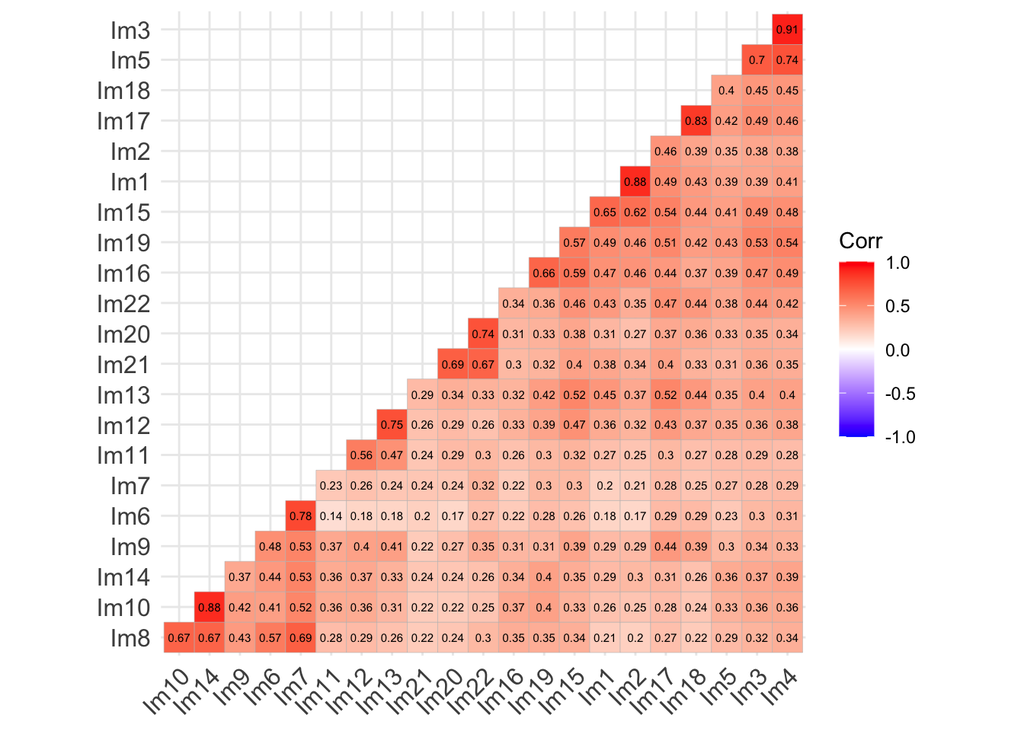

```r
# Select only variables needed for the analysis
Images <- Data %>%
  select(
    Im1:Im22
  )

# Calculate correlation matrix with pairwise handling to avoid dropping rows
cor_matrix_Images <- cor(Images, use = "pairwise.complete.obs")

# Create the correlation plot
ggcorrplot(round(cor_matrix_Images, 2),
           method = "square",
           type = "lower",
           show.diag = FALSE,
           lab = TRUE, lab_col = "black", hc.order = T, lab_size = 2)
```

Most values are sufficient for FA, although some as Im11, Im9 have weaker correlations.

**Check adequacy of correlation matrix**

```r
# Due to NA present in the dataset run Bartlett's test manually on correlation matrix
cortest.bartlett(cor_matrix_Images, n = nrow(Images))
```

```
## $chisq
## [1] 9091.594
##
## $p.value
## [1] 0
##
## $df
## [1] 231
```

```r
# KMO test manually on correlation matrix
KMO(cor_matrix_Images)
```

```
## Kaiser-Meyer-Olkin factor adequacy
## Call: KMO(r = cor_matrix_Images)
## Overall MSA =  0.88
## MSA for each item =
##  Im1  Im2  Im3  Im4  Im5  Im6  Im7  Im8  Im9 Im10 Im11 Im12 Im13 Im14 Im15 Im16
## 0.83 0.82 0.86 0.85 0.96 0.84 0.84 0.93 0.94 0.83 0.93 0.87 0.88 0.84 0.97 0.91
## Im17 Im18 Im19 Im20 Im21 Im22
## 0.87 0.86 0.95 0.86 0.92 0.89
```

The suitability of the dataset for factor analysis was confirmed using Correlation matrix, Bartlett’s Test of Sphericity, the Kaiser-Meyer-Olkin (KMO), MSA measures:

- most of the correlations in the Correlation matrix exceed 0.3.
- Bartlett’s Test of Sphericity was significant (χ²(231) = 9091.594, p < .001), indicating that the correlation matrix is suitable for factor analysis
- The overall Kaiser-Meyer-Olkin (KMO) measure was 0.88, indicating meritorious sampling adequacy. All individual items exceeded the acceptable threshold of 0.80, supporting the suitability of the data for factor analysis.

These results support proceeding with exploratory factor analysis.

## 2.2 **Exploratory Factor Analysis**

To uncover the latent dimensions underlying customer perceptions, an exploratory factor analysis was performed using principal axis factoring (PAF) on the 22 image items.

```r
paf_1 <- fa(subset(Images), nfactors=1) # first select 1 factor to explore results
#Note fa() function from the psych package automatically uses pairwise.complete.obs by default when it calculates the correlation matrix internally, unless you tell it otherwise. So we use all information we have without dropping NA - all good.

print(paf_1$loadings, cutoff=0.3)
```

```
##
## Loadings:
##      MR1
## Im1  0.649
## Im2  0.608
## Im3  0.710
## Im4  0.715
## Im5  0.631
## Im6  0.479
## Im7  0.537
## Im8  0.564
## Im9  0.581
## Im10 0.592
## Im11 0.492
## Im12 0.598
## Im13 0.631
## Im14 0.612
## Im15 0.732
## Im16 0.633
## Im17 0.708
## Im18 0.634
## Im19 0.690
## Im20 0.544
## Im21 0.537
## Im22 0.627
##
##                  MR1
## SS loadings    8.394
## Proportion Var 0.382
```

```r
EigenValue <- paf_1$e.values
Factor_n = as.factor(1:length(paf_1$e.values))

Variance <- EigenValue/ncol(subset(Images))*100

SumVariance <- cumsum(EigenValue/ncol(subset(Images)))


Total_Variance_Explained_paf_1 <- cbind(EigenValue=EigenValue[EigenValue>0],
                                  Variance=Variance[EigenValue>0],
                                  Total_Variance=SumVariance[EigenValue>0])
Total_Variance_Explained_paf_1
```

```
##       EigenValue   Variance Total_Variance
##  [1,] 8.99420362 40.8827437      0.4088274
##  [2,] 2.38352796 10.8342180      0.5171696
##  [3,] 1.52208314  6.9185597      0.5863552
##  [4,] 1.40927515  6.4057962      0.6504132
##  [5,] 1.26357954  5.7435434      0.7078486
##  [6,] 1.11609179  5.0731445      0.7585801
##  [7,] 0.78680722  3.5763965      0.7943440
##  [8,] 0.71954052  3.2706387      0.8270504
##  [9,] 0.56771252  2.5805115      0.8528555
## [10,] 0.48259146  2.1935975      0.8747915
## [11,] 0.38747465  1.7612484      0.8924040
## [12,] 0.34969415  1.5895189      0.9082992
## [13,] 0.33390412  1.5177460      0.9234766
## [14,] 0.30638509  1.3926595      0.9374032
## [15,] 0.28850982  1.3114083      0.9505173
## [16,] 0.23128270  1.0512850      0.9610302
## [17,] 0.22178619  1.0081190      0.9711113
## [18,] 0.18286463  0.8312029      0.9794234
## [19,] 0.15707362  0.7139710      0.9865631
## [20,] 0.11520660  0.5236664      0.9917998
## [21,] 0.09997462  0.4544301      0.9963441
## [22,] 0.08043087  0.3655949      1.0000000
```

The eigenvalue analysis revealed that 6 factors had eigenvalues greater than 1, together explaining approximately 76% of the total variance. The first factor alone explained **40.88%**, while the subsequent factors each explained between **5–10%** of the variance.

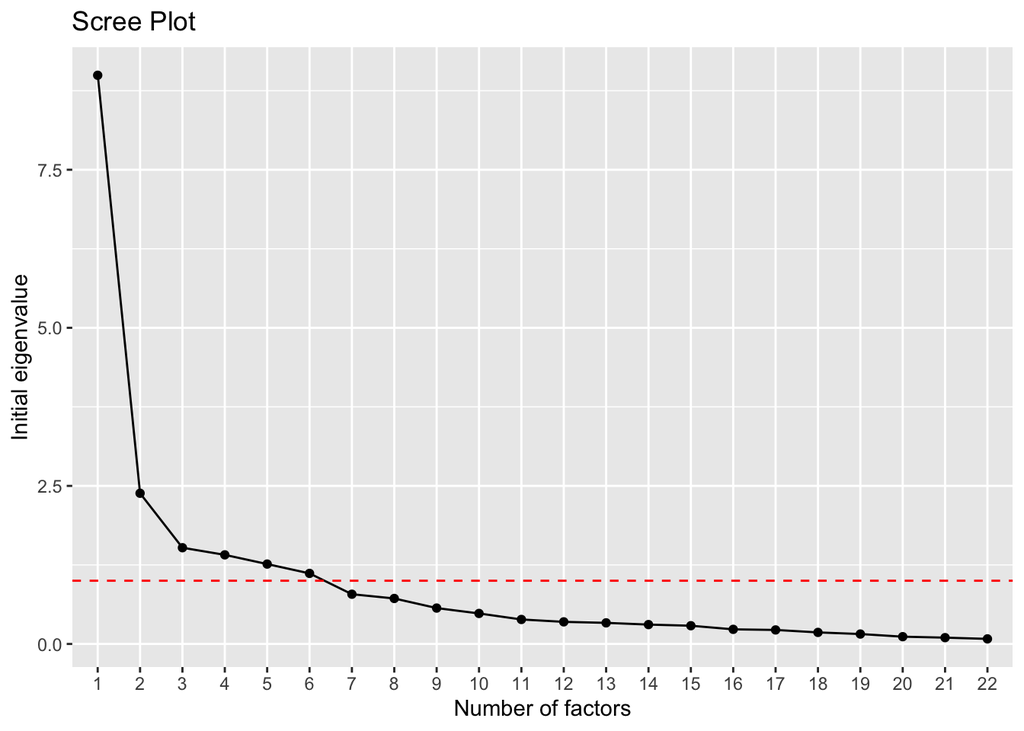

```r
# Scree plot
ggplot(Total_Variance_Explained_paf_1, aes(x = Factor_n, y = EigenValue, group = 1)) +
  geom_point() + geom_line() +
  xlab("Number of factors") +
  ylab("Initial eigenvalue") +
  labs( title = "Scree Plot") +
  geom_hline(yintercept= 1, linetype="dashed", color = "red")
```

On the Scree-plot the elbow seems to be at 6th or 7th factors level, 8 factor is also worth exploring.

To find out the right number of factors 3 possible solution with 6,7 and 8 factors shall be further explored with CFA.

### 2.2.1 **Principal Axis Factoring (PAF) and Confirmatory Factor Analysis (CFA) for 6 Factors**

Based on the 6 eigenvalues above 1, PAF with Varimax rotation was rerun with 6 factors to explore the multidimensional structure of brand perceptions.

```r
paf_6 <- fa(subset(Images), nfactors=6, rotate = "varimax") #  select 6 factors

print(paf_6$loadings, cutoff=0.3)
```

```
##
## Loadings:
##      MR2    MR1    MR4    MR5    MR3    MR6
## Im1          0.857
## Im2          0.852
## Im3                 0.851
## Im4                 0.892
## Im5                 0.650
## Im6   0.702                              0.421
## Im7   0.806                              0.334
## Im8   0.778
## Im9   0.440                0.321         0.325
## Im10  0.753
## Im11                       0.550
## Im12                       0.808
## Im13                       0.728
## Im14  0.737
## Im15         0.588         0.303
## Im16         0.467  0.364
## Im17         0.379  0.303  0.360         0.479
## Im18         0.303  0.306  0.305         0.472
## Im19         0.449  0.405
## Im20                              0.836
## Im21                              0.715
## Im22                              0.776
##
##                  MR2   MR1   MR4   MR5   MR3   MR6
## SS loadings    3.440 2.899 2.856 2.360 2.309 1.092
## Proportion Var 0.156 0.132 0.130 0.107 0.105 0.050
## Cumulative Var 0.156 0.288 0.418 0.525 0.630 0.680
```

```r
EigenValue <- paf_6$e.values

Variance <- EigenValue/ncol(subset(Images))*100

SumVariance <- cumsum(EigenValue/ncol(subset(Images)))


Total_Variance_Explained <- cbind(EigenValue=EigenValue[EigenValue>0],
                                  Variance=Variance[EigenValue>0],
                                  Total_Variance=SumVariance[EigenValue>0])
Total_Variance_Explained
```

```
##       EigenValue   Variance Total_Variance
##  [1,] 8.99420362 40.8827437      0.4088274
##  [2,] 2.38352796 10.8342180      0.5171696
##  [3,] 1.52208314  6.9185597      0.5863552
##  [4,] 1.40927515  6.4057962      0.6504132
##  [5,] 1.26357954  5.7435434      0.7078486
##  [6,] 1.11609179  5.0731445      0.7585801
##  [7,] 0.78680722  3.5763965      0.7943440
##  [8,] 0.71954052  3.2706387      0.8270504
##  [9,] 0.56771252  2.5805115      0.8528555
## [10,] 0.48259146  2.1935975      0.8747915
## [11,] 0.38747465  1.7612484      0.8924040
## [12,] 0.34969415  1.5895189      0.9082992
## [13,] 0.33390412  1.5177460      0.9234766
## [14,] 0.30638509  1.3926595      0.9374032
## [15,] 0.28850982  1.3114083      0.9505173
## [16,] 0.23128270  1.0512850      0.9610302
## [17,] 0.22178619  1.0081190      0.9711113
## [18,] 0.18286463  0.8312029      0.9794234
## [19,] 0.15707362  0.7139710      0.9865631
## [20,] 0.11520660  0.5236664      0.9917998
## [21,] 0.09997462  0.4544301      0.9963441
## [22,] 0.08043087  0.3655949      1.0000000
```

```r
sort(paf_6$communality)
```

```
##      Im11      Im16       Im9      Im19       Im5      Im18      Im21      Im15
## 0.4023366 0.4526431 0.4611696 0.5066775 0.5606778 0.5641024 0.6100245 0.6166821
##      Im17       Im8      Im13       Im6      Im12      Im22      Im14      Im20
## 0.6708146 0.6723146 0.6903164 0.6943148 0.7509279 0.7586800 0.7658650 0.7808819
##      Im10       Im7       Im2       Im1       Im3       Im4
## 0.7865516 0.7899539 0.7940736 0.8374460 0.8640053 0.9251811
```

**Variance Explained:** Explains 68.0% of the total variance.

**Factor Loadings:**

[output not shown]

**Communalities:** Similar low communalities persist for Im11 (0.40), Im16 (0.45), Im9 (0.46), Im19 (0.51). Im18 (0.56) also has a low communality here. This indicates the 6 factors do a poor job explaining the variance in these items.

The factor loadings suggest distinct perceptual dimensions:

| **Factor** | **Included Items** | **Theme** |
| --- | --- | --- |
| **MR2** | Im6, Im7, Im8, Im9, Im10, Im14 | France |
| **MR1** | Im1, Im2, Im15, Im16, Im19 | Assortment |
| **MR4** | Im3, Im4, Im5 | Aesthetic |
| **MR5** | Im11, Im12, Im13 | Quality |
| **MR3** | Im20, Im21, Im22 | Atmosphere |
| **MR6** | Im17, Im18 | Trends |

- *Im9 (French Fashion) is vague, can relate to many things, should be removed.*
- *Im11 (High-quality Cosmetics) has weak loading. Thinking by logic High-quality Cosmetics stands alone and doesn’t directly relate to other variables. But since it doesn’t cross load for the moment - keep it.*
- *It seems that Im17 (Are Trendy) and Im18 (Are Hip) cross load on other factor due to they don’t really relate to any of other variables and nees their own dimension that describes Trends. whether they need their own dimention or not - arguable.*
- *Im16 (Professional Appearance Towards Customers) and Im19 (Professional Organization) represent Assortment but also Professionalism. The variable are vague that’s why they cross load.*

```r
# 6 Factor Model with Im9 removed shows better metrics:
model_6 <- "France =~ Im6 + Im7 + Im8  + Im10 + Im14
          Assortment =~ Im1 + Im2 + Im15 + Im16 + Im19
          Aesthetic =~ Im3 + Im4 + Im5
          Quality =~ Im11 + Im12 + Im13
          Atmosphere =~ Im20 + Im21 + Im22
          Trends =~ Im17 + Im18"

fit_6 <- cfa(model_6,
         data = Images,
         missing = "ML") #ML is to use since we keep NAs. Instead of deleting people with missing answers, all available information was used. The method (FIML) assumes that missing values happen randomly.

summary(fit_6,
        fit.measures = TRUE,
        standardized = TRUE)
```

```
## lavaan 0.6-19 ended normally after 112 iterations
##
##   Estimator                                         ML
##   Optimization method                           NLMINB
##   Number of model parameters                        78
##
##   Number of observations                           553
##   Number of missing patterns                        84
##
## Model Test User Model:
##
##   Test statistic                              1252.416
##   Degrees of freedom                               174
##   P-value (Chi-square)                           0.000
##
## Model Test Baseline Model:
##
##   Test statistic                              8523.596
##   Degrees of freedom                               210
##   P-value                                        0.000
##
## User Model versus Baseline Model:
##
##   Comparative Fit Index (CFI)                    0.870
##   Tucker-Lewis Index (TLI)                       0.843
##
##   Robust Comparative Fit Index (CFI)             0.869
##   Robust Tucker-Lewis Index (TLI)                0.842
##
## Loglikelihood and Information Criteria:
##
##   Loglikelihood user model (H0)             -14618.295
##   Loglikelihood unrestricted model (H1)     -13992.087
##
##   Akaike (AIC)                               29392.590
##   Bayesian (BIC)                             29729.188
##   Sample-size adjusted Bayesian (SABIC)      29481.581
##
## Root Mean Square Error of Approximation:
##
```

[output cut: 113 more lines]

```
##    .Im5               0.744    0.049   15.192    0.000    0.744    0.420
##    .Im11              0.814    0.055   14.807    0.000    0.814    0.622
##    .Im12              0.309    0.040    7.821    0.000    0.309    0.239
##    .Im13              0.390    0.045    8.768    0.000    0.390    0.269
##    .Im20              0.629    0.061   10.378    0.000    0.629    0.281
##    .Im21              0.719    0.057   12.655    0.000    0.719    0.383
##    .Im22              0.556    0.063    8.818    0.000    0.556    0.238
##    .Im17              0.101    0.046    2.197    0.028    0.101    0.065
##    .Im18              0.515    0.055    9.309    0.000    0.515    0.264
##     France            0.412    0.064    6.419    0.000    1.000    1.000
##     Assortment        1.518    0.111   13.732    0.000    1.000    1.000
##     Aesthetic         1.527    0.107   14.305    0.000    1.000    1.000
##     Quality           0.494    0.067    7.361    0.000    1.000    1.000
##     Atmosphere        1.609    0.138   11.685    0.000    1.000    1.000
##     Trends            1.446    0.104   13.878    0.000    1.000    1.000
```

```r
#calculating cronbach alpha
CronFrance <- cronbach(subset(Images, select = c(Im6, Im7, Im8, Im10, Im14)))
CronFrance
```

```
## $sample.size
## [1] 496
##
## $number.of.items
## [1] 5
##
## $alpha
## [1] 0.8821511
```

```r
CronAssortment <- cronbach(subset(Images, select = c(Im1, Im2, Im15, Im16, Im19)))
CronAssortment
```

```
## $sample.size
## [1] 491
##
## $number.of.items
## [1] 5
##
## $alpha
## [1] 0.8787242
```

```r
CronAesthetic <- cronbach(subset(Images, select = c(Im3, Im4, Im5)))
CronAesthetic
```

```
## $sample.size
## [1] 508
##
## $number.of.items
## [1] 3
##
## $alpha
## [1] 0.9151505
```

```r
CronQuality <- cronbach(subset(Images, select = c(Im11, Im12, Im13)))
CronQuality
```

```
## $sample.size
## [1] 520
##
## $number.of.items
## [1] 3
##
## $alpha
## [1] 0.8127499
```

```r
CronAtmosphere <- cronbach(subset(Images, select = c(Im20, Im21, Im22)))
CronAtmosphere
```

```
## $sample.size
## [1] 525
##
## $number.of.items
## [1] 3
##
## $alpha
## [1] 0.8749604
```

```r
CronTrends <- cronbach(subset(Images, select = c(Im17, Im18)))
CronTrends
```

```
## $sample.size
## [1] 521
##
## $number.of.items
## [1] 2
##
## $alpha
## [1] 0.9039139
```

**P-value (Chi-square):** 0, which shows that the model *doesn’t fit good* (in this case we look for p > 0.05, non-significant = good)

**CFI:** 0.87, which is *less than acceptable* ( > 0.90 - acceptable, > 0.95 - excellent)

**TLI:** 0.84, also *not acceptable* ( > 0.90 - acceptable, > 0.95 - excellent)

**RMSEA:** 0.1 means *poor fit* (< 0.08 - acceptable, < 0.06 - excellent)

**Latent Variables (Std.all):** Several loadings are weak, reflecting the poor fit and EFA structure.

```
• Im6 (0.53) is low. Im7 (0.64) is marginal. Forcing diverse items onto one factor strains the loadings.
• Im16 (0.58), Im19 (0.59) are low, again showing the problem of placing these items here.
• Im11 (0.61) is lowish.
```

**Cronbach alphas** are good or excellent.

**Conclusion:** Metrics are unacceptable - this model should not be considered.

### 2.2.2 **Principal Axis Factoring (PAF) and Confirmatory Factor Analysis (CFA) for 7 Factors**

PAF with Varimax rotation was rerun with 7 factors:

```r
paf_7 <- fa(subset(Images), nfactors=7, rotate = "varimax") #  select 7 factors

print(paf_7$loadings, cutoff=0.3)
```

```
##
## Loadings:
##      MR4   MR1   MR2   MR3   MR5   MR7   MR6
## Im1        0.865
## Im2        0.852
## Im3  0.843
## Im4  0.907
## Im5  0.643
## Im6              0.796
## Im7              0.886
## Im8              0.554             0.532
## Im9              0.464       0.325
## Im10                               0.865
## Im11                         0.534
## Im12                         0.863
## Im13                         0.711
## Im14             0.307             0.785
## Im15       0.571
## Im16 0.345 0.435
## Im17                                     0.846
## Im18                                     0.700
## Im19 0.384 0.414
## Im20                   0.837
## Im21                   0.712
## Im22                   0.770
##
##                  MR4   MR1   MR2   MR3   MR5   MR7   MR6
## SS loadings    2.722 2.662 2.340 2.262 2.166 2.049 1.624
## Proportion Var 0.124 0.121 0.106 0.103 0.098 0.093 0.074
## Cumulative Var 0.124 0.245 0.351 0.454 0.552 0.645 0.719
```

```r
EigenValue <- paf_7$e.values

Variance <- EigenValue/ncol(subset(Images))*100

SumVariance <- cumsum(EigenValue/ncol(subset(Images)))


Total_Variance_Explained <- cbind(EigenValue=EigenValue[EigenValue>0],
                                  Variance=Variance[EigenValue>0],
                                  Total_Variance=SumVariance[EigenValue>0])
Total_Variance_Explained
```

```
##       EigenValue   Variance Total_Variance
##  [1,] 8.99420362 40.8827437      0.4088274
##  [2,] 2.38352796 10.8342180      0.5171696
##  [3,] 1.52208314  6.9185597      0.5863552
##  [4,] 1.40927515  6.4057962      0.6504132
##  [5,] 1.26357954  5.7435434      0.7078486
##  [6,] 1.11609179  5.0731445      0.7585801
##  [7,] 0.78680722  3.5763965      0.7943440
##  [8,] 0.71954052  3.2706387      0.8270504
##  [9,] 0.56771252  2.5805115      0.8528555
## [10,] 0.48259146  2.1935975      0.8747915
## [11,] 0.38747465  1.7612484      0.8924040
## [12,] 0.34969415  1.5895189      0.9082992
## [13,] 0.33390412  1.5177460      0.9234766
## [14,] 0.30638509  1.3926595      0.9374032
## [15,] 0.28850982  1.3114083      0.9505173
## [16,] 0.23128270  1.0512850      0.9610302
## [17,] 0.22178619  1.0081190      0.9711113
## [18,] 0.18286463  0.8312029      0.9794234
## [19,] 0.15707362  0.7139710      0.9865631
## [20,] 0.11520660  0.5236664      0.9917998
## [21,] 0.09997462  0.4544301      0.9963441
## [22,] 0.08043087  0.3655949      1.0000000
```

```r
sort(paf_7$communality)
```

```
##      Im11       Im9      Im16      Im19       Im5      Im21      Im15       Im8
## 0.3995643 0.4516927 0.4534528 0.5069038 0.5607649 0.6081676 0.6169174 0.6531156
##      Im13      Im18       Im6      Im22      Im20       Im2      Im14      Im12
## 0.6831805 0.7057034 0.7064504 0.7558723 0.7844055 0.8097673 0.8128267 0.8471416
##       Im3       Im1       Im7      Im10       Im4      Im17
## 0.8630948 0.8673523 0.8935396 0.9115731 0.9592787 0.9741033
```

**Variance Explained:** Explains 71.9% of the total variance. This is generally considered a good amount.

**Loadings:** The structure looks mostly clear, but there are several potentially problematic items:

```
• Im8 (Expertise in French Traditional Cuisine): Loads on MR2 (0.554) and MR7 (0.532) - Clear cross-loading.
• Im9 (French Fashion): Loads primarily on MR2 (0.464) but also weakly on MR5 (0.325).
• Im16 (Professional Appearance Towards Customers): Loads on MR1 (0.435) and MR4 (0.345) - Clear cross-loading, and both loadings are relatively low.
• Im19 (Professional Organization): Loads on MR1 (0.414) and MR4 (0.384) - Clear cross-loading, relatively low loadings.
```

**Communalities:** Im11 (0.40), Im9 (0.45), Im16 (0.45), Im19 (0.51) have the lowest communalities, meaning the 7 factors capture less of their variance. Values below 0.5 are often flagged.

Labeled Factor Structure (7-Factor Solution): New factor Food was formed to separate gastronomy from France.

| **Factor** | **Included Items** | **Theme** |
| --- | --- | --- |
| **MR2** | Im6, Im7, Im8, Im9 | France |
| **MR1** | Im1, Im2, Im15, Im16, Im19 | Assortment |
| **MR4** | Im3, Im4, Im5 | Aesthetic |
| **MR5** | Im11, Im12, Im13 | Quality |
| **MR3** | Im20, Im21, Im22 | Atmosphere |
| **MR6** | Im17, Im18 | Trends |
| **MR7** | Im10, Im14 | Food |

*Im8 (Expertise in French Traditional Cuisine) is highly problematic as it can be associated with France and Food.*

*Im9 (French Fashion) should be removed as before.*

*Im16 (Professional Appearance Towards Customers) and Im19 (Professional Organization) remains problematic - possibly could work better in the separate ddimention of 8 Factor solution.*

**7 Factor model, excluding Im9 and Im8:**

```r
#Removing Im11 gives worse result - should keep it

model_7 <- "France =~ Im6 + Im7
          Assortment =~ Im1 + Im2 + Im15 + Im16 + Im19
          Aesthetic =~ Im3 + Im4 + Im5
          Quality =~ Im11 + Im12 + Im13
          Atmosphere =~ Im20 + Im21 + Im22
          Trends =~ Im17 + Im18
          Food =~ Im10 + Im14"

fit_7 <- cfa(model_7,
         data = Images,
         missing = "ML")

summary(fit_7,
        fit.measures = TRUE,
        standardized = TRUE)
```

```
## lavaan 0.6-19 ended normally after 104 iterations
##
##   Estimator                                         ML
##   Optimization method                           NLMINB
##   Number of model parameters                        81
##
##   Number of observations                           553
##   Number of missing patterns                        82
##
## Model Test User Model:
##
##   Test statistic                               731.749
##   Degrees of freedom                               149
##   P-value (Chi-square)                           0.000
##
## Model Test Baseline Model:
##
##   Test statistic                              7973.741
##   Degrees of freedom                               190
##   P-value                                        0.000
##
## User Model versus Baseline Model:
##
##   Comparative Fit Index (CFI)                    0.925
##   Tucker-Lewis Index (TLI)                       0.905
##
##   Robust Comparative Fit Index (CFI)             0.925
##   Robust Tucker-Lewis Index (TLI)                0.904
##
## Loglikelihood and Information Criteria:
##
##   Loglikelihood user model (H0)             -13825.131
##   Loglikelihood unrestricted model (H1)     -13459.257
##
##   Akaike (AIC)                               27812.262
##   Bayesian (BIC)                             28161.806
##   Sample-size adjusted Bayesian (SABIC)      27904.677
##
## Root Mean Square Error of Approximation:
##
```

[output cut: 119 more lines]

```
##    .Im13              0.389    0.044    8.780    0.000    0.389    0.268
##    .Im20              0.638    0.061   10.474    0.000    0.638    0.285
##    .Im21              0.725    0.057   12.664    0.000    0.725    0.386
##    .Im22              0.542    0.063    8.564    0.000    0.542    0.232
##    .Im17              0.102    0.045    2.246    0.025    0.102    0.066
##    .Im18              0.514    0.055    9.360    0.000    0.514    0.263
##    .Im10              0.123    0.020    6.248    0.000    0.123    0.159
##    .Im14              0.061    0.020    3.112    0.002    0.061    0.081
##     France            0.954    0.095   10.063    0.000    1.000    1.000
##     Assortment        1.519    0.110   13.745    0.000    1.000    1.000
##     Aesthetic         1.528    0.107   14.303    0.000    1.000    1.000
##     Quality           0.495    0.067    7.362    0.000    1.000    1.000
##     Atmosphere        1.599    0.138   11.627    0.000    1.000    1.000
##     Trends            1.445    0.104   13.899    0.000    1.000    1.000
##     Food              0.651    0.050   13.139    0.000    1.000    1.000
```

```r
#calculating cronbach alpha
CronFrance <- cronbach(subset(Images, select = c(Im6, Im7)))
CronFrance
```

```
## $sample.size
## [1] 520
##
## $number.of.items
## [1] 2
##
## $alpha
## [1] 0.8758912
```

```r
CronFood <- cronbach(subset(Images, select = c(Im10, Im14)))
CronFood
```

```
## $sample.size
## [1] 525
##
## $number.of.items
## [1] 2
##
## $alpha
## [1] 0.9334071
```

**P-value (Chi-square):** still 0, which shows that the model *doesn’t fit good* (in this case we look for p > 0.05, non-significant = good), but at the same time Chi-square is sensitive to big datasets and not always reliable.

**CFI:** 0.92, which is exactly *acceptable*

**TLI:** 0.90, *acceptable* ( > 0.90 - acceptable, > 0.95 - excellent)

**RMSEA:** 0.084 is better but still *poor*.

**Latent Variables: (Std.all):**

```
• Im16 on Assortment: 0.58 (Low)
• Im19 on Assortment: 0.59 (Low)
• Im11 on Quality: 0.61 (Lowish)
```

**Cronbach’s Alpha** Results are good or excellent.

**Removing Im8 and Im9 improved the France factor indicators but did not resolve the fundamental issues with the 7-factor structure.**

1. **Poor Overall Fit:** The primary issue is that this model **does not fit the data well** (RMSEA=0.084, CFI/TLI borderline). This poor fit renders detailed interpretation of reliability and validity less meaningful, as the parameter estimates themselves are suspect.
2. **Persistent Measurement Issues:** The analysis confirms that **Assortment** is poorly measured by including `Im16` and `Im19`. If 8th factor solution won’t work well by separating them in a dimention “Profeccionalism” - they should be excluded from 7 Factors model.

**Conclusion**: This model is **not the best solution**. The analysis highlights the persistent problems stemming from forcing items (like Im16, Im19) onto factors where they don’t belong. **8-factor structure** could provide a more accurate and statistically sound representation of the data.

```r
#Local Fit
std.loadings <- inspect(fit_7, what="std")$lambda
check <- std.loadings
check[check>0] <- 1

std.loadings[std.loadings==0] <- NA
std.loadings2 <- std.loadings^2
std.theta<- inspect(fit_7, what="std")$theta

#Individual item Reliability
IIR <- std.loadings2/(colSums(std.theta)+std.loadings2)
IIR
```

```
##      France Assrtm Asthtc Qualty Atmsph Trends  Food
## Im6   0.663     NA     NA     NA     NA     NA    NA
## Im7   0.910     NA     NA     NA     NA     NA    NA
## Im1      NA  0.857     NA     NA     NA     NA    NA
## Im2      NA  0.814     NA     NA     NA     NA    NA
## Im15     NA  0.547     NA     NA     NA     NA    NA
## Im16     NA  0.336     NA     NA     NA     NA    NA
## Im19     NA  0.351     NA     NA     NA     NA    NA
## Im3      NA     NA  0.877     NA     NA     NA    NA
## Im4      NA     NA  0.940     NA     NA     NA    NA
## Im5      NA     NA  0.580     NA     NA     NA    NA
## Im11     NA     NA     NA  0.378     NA     NA    NA
## Im12     NA     NA     NA  0.760     NA     NA    NA
## Im13     NA     NA     NA  0.732     NA     NA    NA
## Im20     NA     NA     NA     NA  0.715     NA    NA
## Im21     NA     NA     NA     NA  0.614     NA    NA
## Im22     NA     NA     NA     NA  0.768     NA    NA
## Im17     NA     NA     NA     NA     NA  0.934    NA
## Im18     NA     NA     NA     NA     NA  0.737    NA
## Im10     NA     NA     NA     NA     NA     NA 0.841
## Im14     NA     NA     NA     NA     NA     NA 0.919
```

```r
#Composite/Construct Reliability
sum.std.loadings<-colSums(std.loadings, na.rm=TRUE)^2
sum.std.theta<-rowSums(std.theta)
sum.std.theta=check*sum.std.theta
CR=sum.std.loadings/(sum.std.loadings+colSums(sum.std.theta))
CR
```

```
##     France Assortment  Aesthetic    Quality Atmosphere     Trends       Food
##  0.8798086  0.8697070  0.9218559  0.8290566  0.8742643  0.9100948  0.9360818
```

```r
#Average Variance Extracted
std.loadings <- inspect(fit_7, what="std")$lambda
std.loadings <- std.loadings^2
AVE=colSums(std.loadings)/(colSums(sum.std.theta)+colSums(std.loadings))
AVE
```

```
##     France Assortment  Aesthetic    Quality Atmosphere     Trends       Food
##  0.7864594  0.5809919  0.7989471  0.6230969  0.6990382  0.8355029  0.8798951
```

```r
std_fit1 <- inspect(fit_7, "std")
std_fit1$psi^2
```

```
##            France Assrtm Asthtc Qualty Atmsph Trends  Food
## France      1.000
## Assortment  0.077  1.000
## Aesthetic   0.112  0.265  1.000
## Quality     0.093  0.283  0.223  1.000
## Atmosphere  0.111  0.242  0.218  0.175  1.000
## Trends      0.104  0.342  0.269  0.322  0.268  1.000
## Food        0.341  0.139  0.174  0.205  0.087  0.106 1.000
```

**Interpretation of the Reliability and Validity Analysis for 7-Factor Model**

This section details the reliability and validity assessment for the 7-factor Confirmatory Factor Analysis (CFA) model (`fit_7`). This model excludes indicators Im8 and Im9 (originally associated with France).

**Individual Item Reliability (IIR):** This measures how much of the variance in each observed variable is explained by its latent factor.

```
• > 0.70 = Good : Im7,Im1, Im2, Im3, Im4, Im12, Im13, Im20, Im22, Im17, Im18, Im10, Im14
• 0.40–0.70 = Acceptable: Im15, Im5, Im21
• < 0.40 = Weak/problematic: Im16, Im19, Im11
```

**Composite Reliability (CR)** Similar to Cronbach’s Alpha — it reflects internal consistency of a latent construct.

```
•   > 0.70 = Acceptable: France, Assortment, Quality, Atmosphere
•   > 0.90 = Excellent: Aesthetic, Trends, Food
```

All constructs are internally consistent.

**Average Variance Extracted (AVE)** This shows convergent validity — i.e., how much of the variance in indicators is explained by the latent factor.

```
•   > 0.50 = Acceptable: Assortment, Quality, Atmosphere
•   > 0.70 = Excellent: France, Aesthetic, Trends, Food
```

Strong convergent validity for all constructs.

**Discriminant Validity (via Fornell-Larcker Criterion)**

Fornell–Larcker Discriminant Validity Results

[output not shown]

**Conclusion on Modified 7-Factor Model (`fit_7`) Reliability & Validity**

The evaluation of the 7-factor measurement model reveals persistent issues with both model fit and construct validity, ultimately suggesting that this structure is not optimal for capturing the underlying dimensions of the Galeries Lafayette brand image.

Although some fit indices (CFI = 0.92, TLI = 0.90) fall into the acceptable range, the RMSEA remains poor at 0.084, and the Chi-square test is significant, indicating a misfit between the model and the data. Given the large sample size, Chi-square significance is expected, but RMSEA and CFI/TLI confirm the model lacks robust support.

From a measurement perspective, several items exhibit weak standardized loadings—notably Im11 (Quality = 0.61), Im16 and Im19 (both on Assortment ≈ 0.58–0.59)—suggesting poor alignment with their intended factors. The forced inclusion of Im16 and Im19 under the Assortment factor weakens the measurement structure and undermines internal consistency.

Although removing problematic items like Im8 and Im9 improved some aspects of the France factor, it did not resolve core model deficiencies. The analysis indicates that Assortment remains a weakly measured construct when including Im16 and Im19.

Introducing an eighth factor—Professionalism—to house Im16 and Im19 could provide better solution.

### 2.2.3 **Principal Axis Factoring (PAF) and Confirmatory Factor Analysis (CFA) for 8 Factors**

```r
paf_8 <- fa(subset(Images), nfactors=8, rotate = "varimax") #  select 8 factors

print(paf_8$loadings, cutoff=0.3)
```

```
##
## Loadings:
##      MR4   MR2   MR3   MR5   MR1   MR7   MR6   MR8
## Im1                          0.885
## Im2                          0.835
## Im3  0.831
## Im4  0.902
## Im5  0.650
## Im6        0.797
## Im7        0.889
## Im8        0.569                   0.503
## Im9        0.469       0.328
## Im10       0.306                   0.827
## Im11                   0.535
## Im12                   0.865
## Im13                   0.718
## Im14       0.302                   0.832
## Im15                   0.311 0.467             0.363
## Im16                                           0.787
## Im17                                     0.823
## Im18                                     0.730
## Im19 0.320                                     0.494
## Im20             0.839
## Im21             0.715
## Im22             0.772
##
##                  MR4   MR2   MR3   MR5   MR1   MR7   MR6   MR8
## SS loadings    2.551 2.391 2.296 2.221 2.157 1.950 1.625 1.264
## Proportion Var 0.116 0.109 0.104 0.101 0.098 0.089 0.074 0.057
## Cumulative Var 0.116 0.225 0.329 0.430 0.528 0.617 0.690 0.748
```

```r
EigenValue <- paf_8$e.values

Variance <- EigenValue/ncol(subset(Images))*100

SumVariance <- cumsum(EigenValue/ncol(subset(Images)))


Total_Variance_Explained <- cbind(EigenValue=EigenValue[EigenValue>0],
                                  Variance=Variance[EigenValue>0],
                                  Total_Variance=SumVariance[EigenValue>0])
Total_Variance_Explained
```

```
##       EigenValue   Variance Total_Variance
##  [1,] 8.99420362 40.8827437      0.4088274
##  [2,] 2.38352796 10.8342180      0.5171696
##  [3,] 1.52208314  6.9185597      0.5863552
##  [4,] 1.40927515  6.4057962      0.6504132
##  [5,] 1.26357954  5.7435434      0.7078486
##  [6,] 1.11609179  5.0731445      0.7585801
##  [7,] 0.78680722  3.5763965      0.7943440
##  [8,] 0.71954052  3.2706387      0.8270504
##  [9,] 0.56771252  2.5805115      0.8528555
## [10,] 0.48259146  2.1935975      0.8747915
## [11,] 0.38747465  1.7612484      0.8924040
## [12,] 0.34969415  1.5895189      0.9082992
## [13,] 0.33390412  1.5177460      0.9234766
## [14,] 0.30638509  1.3926595      0.9374032
## [15,] 0.28850982  1.3114083      0.9505173
## [16,] 0.23128270  1.0512850      0.9610302
## [17,] 0.22178619  1.0081190      0.9711113
## [18,] 0.18286463  0.8312029      0.9794234
## [19,] 0.15707362  0.7139710      0.9865631
## [20,] 0.11520660  0.5236664      0.9917998
## [21,] 0.09997462  0.4544301      0.9963441
## [22,] 0.08043087  0.3655949      1.0000000
```

```r
sort(paf_8$communality)
```

```
##      Im11       Im9       Im5      Im19      Im21      Im15       Im8      Im13
## 0.3988586 0.4525864 0.5778586 0.5838548 0.6087054 0.6281019 0.6562377 0.6875210
##       Im6      Im18      Im22      Im20       Im2      Im16      Im12       Im3
## 0.7046222 0.7394690 0.7565665 0.7862660 0.8280384 0.8366622 0.8440324 0.8623969
##      Im10      Im14       Im7      Im17       Im1       Im4
## 0.8733685 0.8872195 0.8924177 0.9392383 0.9430140 0.9670117
```

**Variance Explained:** Explains 74.8% of the variance, a modest increase (~3%) over the 7-factor solution.

**Loadings:**

```
• The 8th factor (MR8) primarily captures Im16 (0.787) and Im19 (0.494, which is higher than before). This resolves the cross-loading issue for these two items seen in the 7-factor model by giving them their own dimension.
• Im9 (French Fashion)  still show some minor cross-loadings or weak primary loadings similar to the 7-factor solution.
• Im15 (Professional Selection of Brands) now shows loadings on MR5 (0.311), MR1 (0.467), and MR8 (0.363), making it look more complex/problematic in this solution.
• Im8 (Expertise in French Traditional Cuisine) is complex and doesn't cleanly belong to a single factor. It seems related to both the "France" dimension and the "Food" dimension.
```

**Communalities:** Generally similar or slightly improved. Im11 (0.40) and Im9 (0.45) remain low. Im16 and Im19 have higher communalities now.

Labeled Factor Structure (8-Factor Solution):

| **Factor** | **Included Items** | **Theme** |
| --- | --- | --- |
| **MR2** | Im6, Im7, Im8, Im9 | France |
| **MR1** | Im1, Im2, Im15 | Assortment |
| **MR4** | Im3, Im4, Im5 | Aesthetic |
| **MR5** | Im11, Im12, Im13 | Quality |
| **MR3** | Im20, Im21, Im22 | Atmosphere |
| **MR6** | Im17, Im18 | Trends |
| **MR7** | Im10, Im14 | Food |
| **MR8** | Im16, Im19 | Professionalism |

*Im15 (Professional Selection of Brands) now loads on Quality, Assortment and new dimension Professionalism*

Im8, Im9 and Im15 should be removed from 8 Factors solution model:

```r
model_8 <- "France =~ Im6 + Im7
          Assortment =~ Im1 + Im2
          Aesthetic =~ Im3 + Im4 + Im5
          Quality =~ Im11 + Im12 + Im13
          Atmosphere =~ Im20 + Im21 + Im22
          Trends =~ Im17 + Im18
          Food =~ Im10 + Im14
          Professionalism =~ Im16 + Im19"

fit_8 <- cfa(model_8,
         data = Images,
         missing = "ML")

summary(fit_8,
        fit.measures = TRUE,
        standardized = TRUE)
```

```
## lavaan 0.6-19 ended normally after 108 iterations
##
##   Estimator                                         ML
##   Optimization method                           NLMINB
##   Number of model parameters                        85
##
##   Number of observations                           553
##   Number of missing patterns                        79
##
## Model Test User Model:
##
##   Test statistic                               259.047
##   Degrees of freedom                               124
##   P-value (Chi-square)                           0.000
##
## Model Test Baseline Model:
##
##   Test statistic                              7474.765
##   Degrees of freedom                               171
##   P-value                                        0.000
##
## User Model versus Baseline Model:
##
##   Comparative Fit Index (CFI)                    0.982
##   Tucker-Lewis Index (TLI)                       0.975
##
##   Robust Comparative Fit Index (CFI)             0.981
##   Robust Tucker-Lewis Index (TLI)                0.974
##
## Loglikelihood and Information Criteria:
##
##   Loglikelihood user model (H0)             -12973.111
##   Loglikelihood unrestricted model (H1)     -12843.588
##
##   Akaike (AIC)                               26116.223
##   Bayesian (BIC)                             26483.028
##   Sample-size adjusted Bayesian (SABIC)      26213.200
##
## Root Mean Square Error of Approximation:
##
```

[output cut: 126 more lines]

```
##    .Im22              0.541    0.063    8.539    0.000    0.541    0.231
##    .Im17              0.095    0.045    2.112    0.035    0.095    0.062
##    .Im18              0.521    0.055    9.540    0.000    0.521    0.267
##    .Im10              0.114    0.019    5.961    0.000    0.114    0.148
##    .Im14              0.070    0.019    3.680    0.000    0.070    0.093
##    .Im16              0.599    0.052   11.498    0.000    0.599    0.414
##    .Im19              0.338    0.045    7.457    0.000    0.338    0.267
##     France            0.952    0.095   10.058    0.000    1.000    1.000
##     Assortment        1.704    0.118   14.388    0.000    1.000    1.000
##     Aesthetic         1.528    0.107   14.326    0.000    1.000    1.000
##     Quality           0.494    0.067    7.361    0.000    1.000    1.000
##     Atmosphere        1.599    0.138   11.623    0.000    1.000    1.000
##     Trends            1.451    0.104   13.988    0.000    1.000    1.000
##     Food              0.659    0.049   13.328    0.000    1.000    1.000
##     Professionalsm    0.849    0.088    9.638    0.000    1.000    1.000
```

```r
#calculating cronbach alpha

CronAssortment <- cronbach(subset(Images, select = c(Im1, Im2)))
CronAssortment
```

```
## $sample.size
## [1] 525
##
## $number.of.items
## [1] 2
##
## $alpha
## [1] 0.9372013
```

```r
CronProfessionalism <- cronbach(subset(Images, select = c(Im16, Im19)))
CronProfessionalism
```

```
## $sample.size
## [1] 520
##
## $number.of.items
## [1] 2
##
## $alpha
## [1] 0.7940545
```

**CFI:** 0.98, which is *acceptable*

**TLI:** 0.97, is *acceptable*

**RMSEA:** 0.044 - *excellent*

**Latent Variables (Std.all):** Im11 on C: 0.61 (Lowish).

**Cronbach’s Alpha** Results are good or excellent.

```r
#Local Fit
std.loadings <- inspect(fit_8, what="std")$lambda
check <- std.loadings
check[check>0] <- 1

std.loadings[std.loadings==0] <- NA
std.loadings2 <- std.loadings^2
std.theta<- inspect(fit_8, what="std")$theta

#Individual item Reliability
IIR <- std.loadings2/(colSums(std.theta)+std.loadings2)
IIR
```

```
##      France Assrtm Asthtc Qualty Atmsph Trends  Food Prfssn
## Im6   0.661     NA     NA     NA     NA     NA    NA     NA
## Im7   0.912     NA     NA     NA     NA     NA    NA     NA
## Im1      NA  0.960     NA     NA     NA     NA    NA     NA
## Im2      NA  0.808     NA     NA     NA     NA    NA     NA
## Im3      NA     NA  0.878     NA     NA     NA    NA     NA
## Im4      NA     NA  0.940     NA     NA     NA    NA     NA
## Im5      NA     NA  0.578     NA     NA     NA    NA     NA
## Im11     NA     NA     NA  0.378     NA     NA    NA     NA
## Im12     NA     NA     NA  0.760     NA     NA    NA     NA
## Im13     NA     NA     NA  0.731     NA     NA    NA     NA
## Im20     NA     NA     NA     NA  0.715     NA    NA     NA
## Im21     NA     NA     NA     NA  0.614     NA    NA     NA
## Im22     NA     NA     NA     NA  0.769     NA    NA     NA
## Im17     NA     NA     NA     NA     NA  0.938    NA     NA
## Im18     NA     NA     NA     NA     NA  0.733    NA     NA
## Im10     NA     NA     NA     NA     NA     NA 0.852     NA
## Im14     NA     NA     NA     NA     NA     NA 0.907     NA
## Im16     NA     NA     NA     NA     NA     NA    NA  0.586
## Im19     NA     NA     NA     NA     NA     NA    NA  0.733
```

```r
#Composite/Construct Reliability
sum.std.loadings<-colSums(std.loadings, na.rm=TRUE)^2
sum.std.theta<-rowSums(std.theta)
sum.std.theta=check*sum.std.theta
CR=sum.std.loadings/(sum.std.loadings+colSums(sum.std.theta))
CR
```

```
##          France      Assortment       Aesthetic         Quality      Atmosphere
##       0.8799459       0.9384578       0.9215973       0.8289769       0.8742540
##          Trends            Food Professionalism
##       0.9102911       0.9359404       0.7945654
```

```r
#Average Variance Extracted
std.loadings <- inspect(fit_8, what="std")$lambda
std.loadings <- std.loadings^2
AVE=colSums(std.loadings)/(colSums(sum.std.theta)+colSums(std.loadings))
AVE
```

```
##          France      Assortment       Aesthetic         Quality      Atmosphere
##       0.7867075       0.8842421       0.7983932       0.6229767       0.6990222
##          Trends            Food Professionalism
##       0.8358723       0.8796196       0.6598501
```

```r
std_fit1 <- inspect(fit_8, "std")
std_fit1$psi^2
```

```
##                 France Assrtm Asthtc Qualty Atmsph Trends  Food Prfssn
## France           1.000
## Assortment       0.051  1.000
## Aesthetic        0.111  0.194  1.000
## Quality          0.093  0.228  0.222  1.000
## Atmosphere       0.111  0.201  0.218  0.175  1.000
## Trends           0.104  0.270  0.268  0.321  0.267  1.000
## Food             0.343  0.096  0.173  0.205  0.087  0.106 1.000
## Professionalism  0.134  0.356  0.426  0.280  0.228  0.361 0.248  1.000
```

**Reliability and Validity Analysis for Refined 8-Factor Model (`fit_8`)**

This section details the reliability and validity assessment for the refined 8-factor Confirmatory Factor Analysis (CFA) model (`fit_8`). This model includes the “Professionalism” factor (Im16, Im19) and excludes indicators Im8, Im9, and Im15 based on previous refinement steps. Indicator Im11 remains within the Quality factor.

**Individual Item Reliability (IIR)**

This measures how much of the variance in each observed variable is explained by its latent factor.

```
• > 0.70 = Good : Im7,Im1, Im2, Im3, Im4, Im12, Im13, Im20, Im22, Im17, Im18, Im10, Im14, Im19
• 0.40–0.70 = Acceptable: Im6, Im5, Im21
• < 0.40 = Weak/problematic: Im11
```

**Composite Reliability (CR)**

- **Excellent:** **France (0.88), Assortment (0.94), Aesthetic (0.92), Quality (0.83), Atmosphere (0.87), Trends (0.91), Food (0.94)** all demonstrate excellent internal consistency. Their respective indicators work well together.
- **Acceptable:** **Professionalism (0.79)** shows acceptable internal consistency, meeting the threshold.

**Average Variance Extracted (AVE)**

AVE measures the average amount of variance explained by the latent factor across its indicators, indicating convergent validity. An AVE > 0.50 is generally required.

- **PASS (Excellent):** **France (0.79), Assortment (0.88), Aesthetic (0.80), Quality (0.62), Atmosphere (0.70), Trends (0.84), Food (0.88), Professionalism (0.66).** All factors strongly exceed the 0.50 threshold, demonstrating good to excellent convergent validity. The latent factors explain, on average, a substantial majority of the variance in their indicators.

**Discriminant Validity (via Fornell-Larcker Criterion)**

Discriminant validity assesses whether latent factors represent truly distinct concepts. Using the Fornell-Larcker criterion, the AVE of a factor should be greater than its squared correlation (shared variance) with any other factor.

Fornell–Larcker Discriminant Validity Results (8-Factor Model)

| Factor | AVE | Max_Squared_Correlation | Conclusion |
| --- | --- | --- | --- |
| France | 0.787 | 0.343 | ✓ Pass |
| Assortment | 0.884 | 0.356 | ✓ Pass |
| Aesthetic | 0.798 | 0.426 | ✓ Pass |
| Quality | 0.623 | 0.321 | ✓ Pass |
| Atmosphere | 0.699 | 0.267 | ✓ Pass |
| Trends | 0.836 | 0.361 | ✓ Pass |
| Food | 0.880 | 0.343 | ✓ Pass |
| Professionalism | 0.660 | 0.426 | ✓ Pass |

**All factors demonstrate adequate discriminant validity** based on the Fornell-Larcker criterion in this model. The AVE for each factor is comfortably higher than its squared correlation with any other factor.

**Conclusion on Refined 8-Factor Model (`fit_8`) Reliability & Validity**

This refined 8-factor model (`fit_8`) demonstrates **strong psychometric properties**:

1. **Excellent Overall Fit:** The model fits the data extremely well, providing a solid foundation for assessing reliability and validity.
2. **Strong Convergent Validity:** All factors meet and exceed the AVE > 0.50 criterion.
3. **Strong Discriminant Validity:** All factors are shown to be distinct from one another based on the Fornell-Larcker criterion.
4. **Good Internal Consistency:** All factors exhibit good to excellent composite reliability (CR > 0.70).
5. **Generally Good Item Reliability:** Most individual items reliably measure their intended factors. The primary exception is `Im11` within the Quality factor, which consistently shows lower reliability compared to other items.

**Conclusion:** This model (`fit_8`) is a very strong candidate for the final model. The only remaining consideration is the relatively weak performance of `Im11`. Although the standardized loading for Im11 (≈ 0.615) is lower relative to other indicators in the final model, it remains statistically significant (p < 0.001). This loading indicates that Im11 still shares approximately 38% of its variance with the ‘Quality’ factor, representing a substantive, non-negligible contribution to the construct’s measurement within this well-fitting model.

### 2.2.4 **Overall Conclusion: Model Comparison and Selection**

The objective of this analysis was to identify the most appropriate factor structure underlying the 22 `Im` items measuring perceptions of GLB. Several models based on Exploratory Factor Analysis (EFA) suggesting 6, 7, and 8 factors were specified and tested using Confirmatory Factor Analysis (CFA). This was followed by iterative refinement based on fit statistics, parameter estimates, and theoretical considerations to arrive at a final, well-fitting, and theoretically sound model.

**Evaluation of 6-Factor Models**

The 6-factor EFA revealed a problematic structure. Notably, it merged conceptually distinct items (e.g., related to France and Food) into single factors and exhibited numerous complex cross-loadings. The corresponding CFA confirmed this inadequacy with **extremely poor model fit**. The 6-factor structure was **rejected**.

**Evaluation of 7-Factor Models**

The 7-factor CFA structure, mapped directly from the EFA, also exhibited **poor overall model fit** (RMSEA ≈ 0.084, CFI/TLI ≈ 0.90), indicating inadequacy. Key issues included:

- The cross-loading behaviour of `Im8`.
- The problematic assignment of `Im16` and `Im19` to the “Assortment” factor, where they loaded weakly.

While better than the 6-factor solutions, the 7-factor structure did not provide an optimal representation of the data and was **not selected as the final model**.

**Evaluation of 8-Factor Models**

Subsequent refinement involved removing items identified as problematic across analyses:

- `Im8` and `Im9` (weak/complex loadings on “France”, cross-loading issues).
- `Im15` (weakest loading on “Assortment” after other removals).

This iterative process led to the final recommended model (`fit_8`): an 8-factor structure with “Professionalism” as a distinct factor, and items `Im8`, `Im9`, and `Im15` removed. This model demonstrated **outstanding statistical fit** across all indices (RMSEA = 0.044, CFI = 0.982, TLI = 0.975, SRMR = 0.029), strongly indicating it aligns well with the observed data.

**Measurement Quality of Recommended 8-Factor Model (`fit_8`)**

This model exhibited strong psychometric properties:

- **Reliability:** Excellent Composite Reliability (CR > 0.79) for all factors.
- **Convergent Validity:** Excellent Average Variance Extracted (AVE > 0.62) for all factors, indicating indicators strongly converge on their respective constructs.
- **Discriminant Validity:** All factors demonstrated clear discriminant validity based on the Fornell-Larcker criterion (AVE > R² with other factors).
- **Item Reliability:** Most indicators showed strong individual reliability (high squared loadings). The only exception was `Im11` (“High-quality Cosmetics”) loading on “Quality” (Std. loading ≈ 0.615), which showed moderate reliability.

**Final Model Justification (`fit_8`)**

The refined 8-factor model (`fit_8`) is selected as the **best solution**. It provides a **superior statistical fit** compared to the 6- and 7-factor alternatives and addresses the structural misspecifications inherent in those models by identifying a distinct and meaningful “Professionalism” factor. This model demonstrates **strong reliability, convergent validity, and discriminant validity** for all constructs.

The decision was made to **retain `Im11`** within this final model despite its lower relative loading, based on:

1. The excellent overall model fit achieved *with* the item included.
2. Its contribution to the content validity of the “Quality” factor (representing product quality alongside brand prestige).
3. The benefit of maintaining three indicators for factor stability.

In conclusion, the final 8-factor model (`fit_8`), incorporating the “Professionalism” dimension and refined through the removal of items Im8, Im9, and Im15, offers the most statistically robust, reliable, valid, and theoretically coherent representation of the structure underlying the perception of GLB based on the analyzed data.

# 3 **Question 2: Are the mechanism driving satisfaction and affective commitment similar? Are satisfaction and affective commitment mediating the impact of image perceptions on outcomes? If yes for which outcomes?**

```r
# Define the full model

model <- '
  # Measurement Model (Loadings -  Validated)
  France =~ Im6 + Im7
  Assortment =~ Im1 + Im2
  Aesthetic =~ Im3 + Im4 + Im5
  Quality =~ Im11 + Im12 + Im13
  Atmosphere =~ Im20 + Im21 + Im22
  Trends =~ Im17 + Im18
  Food =~ Im10 + Im14
  Professionalism =~ Im16 + Im19

  Satisfaction =~ SAT_1 + SAT_2 + SAT_3                    #added accordingly to the task
  AffectiveCommitment =~ COM_A1 + COM_A2 + COM_A3 + COM_A4
  RepurchaseIntention =~ C_REP1 + C_REP2 + C_REP3
  CocreationIntention =~ C_CR1 + C_CR3 + C_CR4

  # Structural Model (Regressions)
  # Predicting Mediators (SAT and AC) from Image Factors (Paths a)
  Satisfaction ~ a1*France + a2*Assortment + a3*Aesthetic + a4*Quality + a5*Atmosphere + a6*Trends + a7*Food + a8*Professionalism
  AffectiveCommitment ~ a9*France + a10*Assortment + a11*Aesthetic + a12*Quality + a13*Atmosphere + a14*Trends + a15*Food + a16*Professionalism

  # Predicting Outcomes from Mediators (Paths b)
  RepurchaseIntention ~ b1*Satisfaction + b2*AffectiveCommitment
  CocreationIntention ~ b3*Satisfaction + b4*AffectiveCommitment

  # Direct Effects from Image Factors to Outcomes (Paths c)
  RepurchaseIntention ~ c1*France + c2*Assortment + c3*Aesthetic + c4*Quality + c5*Atmosphere + c6*Trends + c7*Food + c8*Professionalism
  CocreationIntention ~ c9*France + c10*Assortment + c11*Aesthetic + c12*Quality + c13*Atmosphere + c14*Trends + c15*Food + c16*Professionalism

  # Indirect Effects for Mediation Testing
  # Format: effect_name := path1_label * path2_label

  # Repurchase Intention:
  France_SAT_RI := a1 * b1
  Assortment_SAT_RI := a2 * b1
  Aesthetic_SAT_RI := a3 * b1
  Quality_SAT_RI := a4 * b1
  Atmosphere_SAT_RI := a5 * b1
  Trends_SAT_RI := a6 * b1
  Food_SAT_RI := a7 * b1
  Professionalism_SAT_RI := a8 * b1

  France_AC_RI := a9 * b2
  Assortment_AC_RI := a10 * b2
  Aesthetic_AC_RI := a11 * b2
  Quality_AC_RI := a12 * b2
  Atmosphere_AC_RI := a13 * b2
  Trends_AC_RI := a14 * b2
  Food_AC_RI := a15 * b2
  Professionalism_AC_RI := a16 * b2


  # Cocreation Intention:
  France_SAT_CI := a1 * b3
  Assortment_SAT_CI := a2 * b3
  Aesthetic_SAT_CI := a3 * b3
  Quality_SAT_CI := a4 * b3
  Atmosphere_SAT_CI := a5 * b3
  Trends_SAT_CI := a6 * b3
  Food_SAT_CI := a7 * b3
  Professionalism_SAT_CI := a8 * b3

  France_AC_CI := a9 * b4
  Assortment_AC_CI := a10 * b4
  Aesthetic_AC_CI := a11 * b4
  Quality_AC_CI := a12 * b4
  Atmosphere_AC_CI := a13 * b4
  Trends_AC_CI := a14 * b4
  Food_AC_CI := a15 * b4
  Professionalism_AC_CI := a16 * b4


  # Total Effects (Direct + Indirect)
  France_Total_RI := c1 + (a1*b1) + (a9*b2)
  Assortment_Total_RI := c2 + (a2*b1) + (a10*b2)
  Aesthetic_Total_RI := c3 + (a3*b1) + (a11*b2)
  Quality_Total_RI := c4 + (a4*b1) + (a12*b2)
  Atmosphere_Total_RI := c5 + (a5*b1) + (a13*b2)
  Trends_Total_RI := c6 + (a6*b1) + (a14*b2)
  Food_Total_RI := c7 + (a7*b1) + (a15*b2)
  Professionalism_Total_RI := c8 + (a8*b1) + (a16*b2)

  France_Total_CI := c9 + (a1*b3) + (a9*b4)
  Assortment_Total_CI := c10 + (a2*b3) + (a10*b4)
  Aesthetic_Total_CI := c11 + (a3*b3) + (a11*b4)
  Quality_Total_CI := c12 + (a4*b3) + (a12*b4)
  Atmosphere_Total_CI := c13 + (a5*b3) + (a13*b4)
  Trends_Total_CI := c14 + (a6*b3) + (a14*b4)
  Food_Total_CI := c15 + (a7*b3) + (a15*b4)
  Professionalism_Total_CI := c16 + (a8*b3) + (a16*b4)
'

# Fit the  model
fit <- cfa(model, data = Data, missing = "ML")

summary(fit, fit.measures=TRUE,standardized=TRUE)
```

```
## lavaan 0.6-19 ended normally after 149 iterations
##
##   Estimator                                         ML
##   Optimization method                           NLMINB
##   Number of model parameters                       161
##
##   Number of observations                           553
##   Number of missing patterns                       135
##
## Model Test User Model:
##
##   Test statistic                               700.455
##   Degrees of freedom                               399
##   P-value (Chi-square)                           0.000
##
## Model Test Baseline Model:
##
##   Test statistic                             11978.557
##   Degrees of freedom                               496
##   P-value                                        0.000
##
## User Model versus Baseline Model:
##
##   Comparative Fit Index (CFI)                    0.974
##   Tucker-Lewis Index (TLI)                       0.967
##
##   Robust Comparative Fit Index (CFI)             0.974
##   Robust Tucker-Lewis Index (TLI)                0.968
##
## Loglikelihood and Information Criteria:
##
##   Loglikelihood user model (H0)             -22368.900
##   Loglikelihood unrestricted model (H1)     -22018.673
##
##   Akaike (AIC)                               45059.800
##   Bayesian (BIC)                             45754.573
##   Sample-size adjusted Bayesian (SABIC)      45243.488
##
## Root Mean Square Error of Approximation:
##
```

[output cut: 271 more lines]

```
##     Assrtmnt_Tt_RI    0.031    0.028    1.109    0.267    0.067    0.067
##     Aesthtc_Ttl_RI   -0.018    0.030   -0.592    0.554   -0.037   -0.037
##     Quality_Ttl_RI    0.034    0.055    0.628    0.530    0.040    0.040
##     Atmsphr_Ttl_RI    0.120    0.028    4.255    0.000    0.254    0.254
##     Trends_Totl_RI   -0.012    0.032   -0.383    0.702   -0.025   -0.025
##     Food_Total_RI     0.060    0.047    1.280    0.200    0.082    0.082
##     Prfssnlsm_T_RI    0.091    0.058    1.563    0.118    0.141    0.141
##     France_Totl_CI   -0.042    0.106   -0.395    0.693   -0.025   -0.025
##     Assrtmnt_Tt_CI    0.001    0.083    0.011    0.991    0.001    0.001
##     Aesthtc_Ttl_CI   -0.006    0.092   -0.060    0.952   -0.004   -0.004
##     Quality_Ttl_CI    0.108    0.164    0.657    0.511    0.046    0.046
##     Atmsphr_Ttl_CI    0.337    0.084    4.021    0.000    0.256    0.256
##     Trends_Totl_CI    0.010    0.096    0.101    0.920    0.007    0.007
##     Food_Total_CI    -0.093    0.141   -0.663    0.508   -0.045   -0.045
##     Prfssnlsm_T_CI   -0.253    0.172   -1.470    0.142   -0.140   -0.140
```

```r
parameterestimates(fit, boot.ci.type = "bca.simple", standardized = TRUE)%>% kable()
```

| lhs | op | rhs | label | est | se | z | pvalue | ci.lower | ci.upper | std.lv | std.all |
| --- | --- | --- | --- | --- | --- | --- | --- | --- | --- | --- | --- |
| France | =~ | Im6 |  | 1.0000000 | 0.0000000 | NA | NA | 1.0000000 | 1.0000000 | 0.9866635 | 0.8224948 |
| France | =~ | Im7 |  | 1.1581078 | 0.0650719 | 17.7973573 | 0.0000000 | 1.0305692 | 1.2856463 | 1.1426627 | 0.9443321 |
| Assortment | =~ | Im1 |  | 1.0000000 | 0.0000000 | NA | NA | 1.0000000 | 1.0000000 | 1.2968201 | 0.9742554 |
| Assortment | =~ | Im2 |  | 0.8957971 | 0.0316295 | 28.3215470 | 0.0000000 | 0.8338044 | 0.9577899 | 1.1616878 | 0.9040539 |
| Aesthetic | =~ | Im3 |  | 1.0000000 | 0.0000000 | NA | NA | 1.0000000 | 1.0000000 | 1.2354504 | 0.9364567 |
| Aesthetic | =~ | Im4 |  | 1.0568701 | 0.0247325 | 42.7321015 | 0.0000000 | 1.0083954 | 1.1053448 | 1.3057105 | 0.9697608 |
| Aesthetic | =~ | Im5 |  | 0.8179436 | 0.0343582 | 23.8063775 | 0.0000000 | 0.7506028 | 0.8852843 | 1.0105287 | 0.7599617 |
| Quality | =~ | Im11 |  | 1.0000000 | 0.0000000 | NA | NA | 1.0000000 | 1.0000000 | 0.7005935 | 0.6126692 |
| Quality | =~ | Im12 |  | 1.4141425 | 0.0942361 | 15.0063722 | 0.0000000 | 1.2294431 | 1.5988419 | 0.9907391 | 0.8720651 |
| Quality | =~ | Im13 |  | 1.4684671 | 0.1054289 | 13.9285114 | 0.0000000 | 1.2618303 | 1.6751038 | 1.0287985 | 0.8550087 |
| Atmosphere | =~ | Im20 |  | 1.0000000 | 0.0000000 | NA | NA | 1.0000000 | 1.0000000 | 1.2615091 | 0.8436600 |
| Atmosphere | =~ | Im21 |  | 0.8573061 | 0.0408256 | 20.9992328 | 0.0000000 | 0.7772894 | 0.9373227 | 1.0814994 | 0.7892214 |
| Atmosphere | =~ | Im22 |  | 1.0564905 | 0.0458685 | 23.0330212 | 0.0000000 | 0.9665899 | 1.1463911 | 1.3327724 | 0.8725064 |
| Trends | =~ | Im17 |  | 1.0000000 | 0.0000000 | NA | NA | 1.0000000 | 1.0000000 | 1.2052872 | 0.9696704 |
| Trends | =~ | Im18 |  | 0.9919297 | 0.0411446 | 24.1083936 | 0.0000000 | 0.9112878 | 1.0725716 | 1.1955602 | 0.8554049 |
| Food | =~ | Im10 |  | 1.0000000 | 0.0000000 | NA | NA | 1.0000000 | 1.0000000 | 0.8096065 | 0.9205851 |
| Food | =~ | Im14 |  | 1.0209403 | 0.0356407 | 28.6453315 | 0.0000000 | 0.9510858 | 1.0907949 | 0.8265599 | 0.9550814 |
| Professionalism | =~ | Im16 |  | 1.0000000 | 0.0000000 | NA | NA | 1.0000000 | 1.0000000 | 0.9191070 | 0.7642380 |
| Professionalism | =~ | Im19 |  | 1.0431148 | 0.0583983 | 17.8620768 | 0.0000000 | 0.9286563 | 1.1575734 | 0.9587341 | 0.8526493 |
| Satisfaction | =~ | SAT_1 |  | 1.0000000 | 0.0000000 | NA | NA | 1.0000000 | 1.0000000 | 0.8821715 | 0.8648718 |
| Satisfaction | =~ | SAT_2 |  | 0.9331804 | 0.0493346 | 18.9153182 | 0.0000000 | 0.8364863 | 1.0298746 | 0.8232252 | 0.8191678 |
| Satisfaction | =~ | SAT_3 |  | 0.8093065 | 0.0546823 | 14.8001631 | 0.0000000 | 0.7021312 | 0.9164818 | 0.7139472 | 0.6243907 |
| AffectiveCommitment | =~ | COM_A1 |  | 1.0000000 | 0.0000000 | NA | NA | 1.0000000 | 1.0000000 | 1.1437166 | 0.7959573 |
| AffectiveCommitment | =~ | COM_A2 |  | 1.1735501 | 0.0545919 | 21.4967623 | 0.0000000 | 1.0665518 | 1.2805483 | 1.3422086 | 0.8355335 |
| AffectiveCommitment | =~ | COM_A3 |  | 1.1621218 | 0.0580286 | 20.0267021 | 0.0000000 | 1.0483878 | 1.2758558 | 1.3291380 | 0.8169603 |
| AffectiveCommitment | =~ | COM_A4 |  | 1.2782630 | 0.0614530 | 20.8006711 | 0.0000000 | 1.1578174 | 1.3987086 | 1.4619705 | 0.8423579 |
| RepurchaseIntention | =~ | C_REP1 |  | 1.0000000 | 0.0000000 | NA | NA | 1.0000000 | 1.0000000 | 0.5962924 | 0.8157839 |
| RepurchaseIntention | =~ | C_REP2 |  | 0.9709616 | 0.0431752 | 22.4888756 | 0.0000000 | 0.8863398 | 1.0555834 | 0.5789770 | 0.9312793 |
| RepurchaseIntention | =~ | C_REP3 |  | 0.7020820 | 0.0368804 | 19.0367373 | 0.0000000 | 0.6297978 | 0.7743662 | 0.4186462 | 0.7559879 |
| CocreationIntention | =~ | C_CR1 |  | 1.0000000 | 0.0000000 | NA | NA | 1.0000000 | 1.0000000 | 1.6580215 | 0.8509709 |

[output cut: 203 more lines]

Standardized Effects (β) of Image Dimensions on Satisfaction vs. Affective Commitment

| Factor | Beta_Satisfaction | Beta_AffectiveCommitment |
| --- | --- | --- |
| France | 0.115 | 0.192 |
| Assortment | 0.197 | 0.114 |
| Aesthetic | -0.152 | -0.026 |
| Quality | -0.030 | -0.115 |
| Atmosphere | 0.074 | 0.411 |
| Trends | 0.011 | -0.019 |
| Food | 0.074 | 0.020 |
| Professionalism | 0.479 | 0.129 |

## 3.1 **Interpretation by Factor**

- **France**: Positively influences both Satisfaction (β = 0.115) and Affective Commitment (β = 0.192). Its emotional and cultural value seems to enhance both immediate satisfaction and deeper emotional loyalty.
- **Assortment**: Also positively influences both mediators, but more strongly Satisfaction (β = 0.197) than Affective Commitment (β = 0.114). This indicates its role is more functional and tied to customer utility than to brand attachment.
- **Aesthetic**: Has a significant negative impact on Satisfaction (β = -0.152), suggesting perhaps overly stylized design may reduce comfort or usability. It shows no notable effect on Affective Commitment (β = -0.026).
- **Quality**: Shows weak or no impact on Satisfaction (β = -0.030), but a negative marginal effect on Affective Commitment (β = -0.115). This could reflect that perceived quality alone doesn’t build emotional connection, and poor quality may even damage loyalty.
- **Atmosphere**: A key driver for Affective Commitment (β = 0.411), but only weakly impacts Satisfaction (β = 0.074). This indicates that store atmosphere plays a much stronger role in emotional attachment than in functional satisfaction.
- **Trends**: Very weak effects on both mediators (Satisfaction β = 0.011, AC β = -0.019), suggesting trendiness isn’t a central factor in shaping satisfaction or emotional connection.
- **Food**: Small, non-significant effects on both (Satisfaction β = 0.074, AC β = 0.020). It likely enhances the environment, but doesn’t drive either satisfaction or emotional loyalty directly.
- **Professionalism**: The strongest predictor of Satisfaction (β = 0.479), reflecting the value customers place on professional service. Its effect on Affective Commitment is smaller and not significant (β = 0.129), suggesting service quality builds satisfaction more than emotional loyalty.

The mechanisms driving **Satisfaction** and **Affective Commitment** are not identical:

- **Satisfaction** is primarily influenced by **Professionalism and Assortment**, reflecting a functional, service-quality-driven response.
- **Affective Commitment** is driven most strongly by **Atmosphere and France** — more experiential and emotional elements.

Thus, while some overlap exists (e.g., France and Assortment affect both), each mediator is shaped by distinct dominant drivers, meaning they function via different psychological mechanisms.

Mediating Effects of Satisfaction and Affective Commitment on Behavioral Outcomes

| Mediator | Outcome | Beta | Significance | Direction |
| --- | --- | --- | --- | --- |
| Satisfaction | Repurchase Intention | 0.318 | *** | Positive |
| Satisfaction | Cocreation Intention | -0.190 | ** | Negative |
| Affective Commitment | Repurchase Intention | 0.354 | *** | Positive |
| Affective Commitment | Cocreation Intention | 0.377 | *** | Positive |

**Repurchase Intention:**

**Both Satisfaction and Affective Commitment** significantly predict Repurchase Intention:

```
•   Satisfaction → RI: β = 0.318 (p < .001)
•   Affective Commitment → RI: β = 0.354 (p < .001)
```

This means both mediate the relationship between store image perceptions and Repurchase Intention. Several significant indirect effects confirm this:

```
•   Professionalism → Satisfaction → RI: β = 0.152 (p < .001)
•   Atmosphere → Affective Commitment → RI: β = 0.145 (p < .001)
•   France → Affective Commitment → RI: β = 0.068 (p = .003)
```

Satisfaction and Affective Commitment both mediate effects on Repurchase Intention. Professionalism acts mostly via Satisfaction, while France and Atmosphere act via Affective Commitment.

**Cocreation Intention**

This is more nuanced:

```
•   Affective Commitment → CI: β = 0.377 (p < .001)
•   Satisfaction → CI: β = -0.190 (p = .007)
```

So:

```
•   Affective Commitment positively mediates effects on Cocreation Intention.
•   Satisfaction negatively mediates — meaning higher Satisfaction reduces Cocreation intent.
```

Confirmed by indirect effects:

```
•   Atmosphere → Affective Commitment → CI: β = 0.155 (p < .001)
•   France → Affective Commitment → CI: β = 0.072 (p = .002)
•   Professionalism → Satisfaction → CI: β = –0.091 (p = .014)
```

Only **Affective Commitment** is a positive mediator for **Cocreation Intention**. Satisfaction acts as a negative mediator, meaning that overly satisfied customers may not be interested in engaging further in cocreation activities.

## 3.2 Conclusion

The mechanisms driving **Satisfaction** and **Affective Commitment** are partially overlapping but fundamentally distinct.

While both are influenced by certain store image dimensions such as **France and Assortment**, **Satisfaction** is primarily driven by **Professionalism** (β = 0.479, p < .001) and negatively impacted by **Aesthetic** perception, indicating a focus on cognitive, evaluative judgments.

In contrast, **Affective Commitment** is more strongly influenced by **Atmosphere** (β = 0.411, p < .001), reflecting an emotional attachment.

Both mediators significantly transmit the effects of image perceptions to customer behaviors: **Satisfaction and Affective Commitment** mediate **Repurchase Intention** while **Affective Commitment** also mediates **Cocreation Intention** positively. Interestingly, **Satisfaction negatively** mediates the effect of some image dimensions on **Cocreation** indicating potential trade-offs between customer contentment and active engagement. Thus, both mediators play crucial—but distinct—roles in linking store perceptions to customer outcomes.

# 4 **Question 3: What is driving the two distinct outcomes (repurchase and co-creation intention): Please rank the image dimensions with respect to the total effect on each outcome? Interpret your results.**

## 4.1 Drivers of Repurchase Intention

### 4.1.1 Ranking of Total Effects on Repurchase Intention

| Dimension | β_total | p-value | Significance |
| --- | --- | --- | --- |
| Atmosphere | 0.254 | <0.001 | *** Significant *** |
| Professionalism | 0.141 | 0.118 | Not Significant |
| Food | 0.082 | 0.200 | Not Significant |
| Assortment | 0.067 | 0.267 | Not Significant |
| France | 0.049 | 0.404 | Not Significant |
| Quality | 0.040 | 0.530 | Not Significant |
| Aesthetic | -0.037 | 0.554 | Not Significant |
| Trends | -0.025 | 0.702 | Not Significant |

### 4.1.2 Interpretation for Repurchase Intention

Atmosphere has a statistically significant positive total effect on Repurchase Intention, mainly driven by its indirect path through Affective Commitment (Atmosphere → AC → RI with β = 0.145). Professionalism has the second-highest impact but is not statistically significant (p = 0.118). Other image dimensions, although influential to mediators, do not show significant total effects on Repurchase Intention.

## 4.2 Drivers of Cocreation Intention (CI)

### 4.2.1 Ranking of Total Effects on Cocreation Intention

| Dimension | β_total | p-value | Significance |
| --- | --- | --- | --- |
| Atmosphere | 0.256 | <0.001 | *** Significant *** |
| Professionalism | -0.140 | 0.142 | Not Significant |
| Quality | 0.046 | 0.511 | Not Significant |
| Food | -0.045 | 0.508 | Not Significant |
| France | -0.025 | 0.693 | Not Significant |
| Trends | 0.007 | 0.920 | Not Significant |
| Aesthetic | -0.004 | 0.952 | Not Significant |
| Assortment | 0.001 | 0.991 | Not Significant |

### 4.2.2 Interpretation for Cocreation Intention

Atmosphere again emerges as the only significant dimension positively affecting Cocreation Intention, mainly via Affective Commitment (Atmosphere → AC → CI with β = 0.155). Professionalism’s overall impact is negative but not significant due to conflicting pathways (positive via Affective Commitment but negative via Satisfaction).

## 4.3 Overall Conclusion

Among the store image dimensions, **Atmosphere** is the strongest and only statistically significant driver of **both Repurchase Intention (β_total = 0.254, p < .001) and Cocreation Intention (β_total = 0.256, p < .001)**, largely due to its strong positive indirect effects via **Affective Commitment**.

For **Repurchase Intention**, **Atmosphere** is followed by **Professionalism** (β_total = 0.141), Food (β = 0.082), and **Assortment** (β = 0.067), though none of these are statistically significant. The remaining dimensions (France, Quality, Aesthetic, and Trends) show negligible or negative effects.

For **Cocreation Intention**, **Atmosphere** is again dominant, with **Professionalism** showing a negative but non-significant total effect (β = –0.140), likely due to the negative mediation via **Satisfaction**. All other dimensions—including Quality, Food, France, Trends, Aesthetic, and Assortment—have minimal and non-significant total effects.

**These findings highlight that Atmosphere is the only reliable and consistent predictor of both behavioral outcomes, underscoring its importance in shaping emotional connection and future customer actions.**